# Coursera R Programming

Chen Qingqing

19/03/2018

# 1 Getting Started with R

## 1.1 Data Types

### 1.1.1 Objects

- character
- numeric (real number)
- integer
- complex
- logical(Ture/False)
- The most basic object is vector
  - A vector can only contain objects of the same class
  - BUT: The one exception is a list, which is represented as a vector but can contain objects of different classes
  - Empty vectors can be created with the vector() function

### 1.1.2 Numbers

- Generally treated as numeric objects
- If you explicitly want an integer, need to specify the `L` suffix, eg. 1L explicitly gives you an integer
- Special number `Inf` which represents infinity
- `NaN` represents **undefined value (“not a number”)**

### 1.1.3 Attributes

R objects can have attributes - names, dimnames - dimensions (e.g. matrices, arrays) - class - length - other user-defined attributes/metadata - Attribute of an object can be accessed using the `attributes()` function

### 1.1.4 Vectors

- The c() function can be used to create vectors of objects
- Mixing Objects: when different objects are mixed in a vector, coercion occurs so that every element in the vector is of the same class
- Objects can be explicitly coerced from one class to another using the `as.functions`

```r
x <- 0:6
x
```

```
## [1] 0 1 2 3 4 5 6
```

```r
class(x)
```

```
## [1] "integer"
```

```r
as.numeric(x)
```

```
## [1] 0 1 2 3 4 5 6
```

```r
as.logical(x)
```

```
## [1] FALSE  TRUE  TRUE  TRUE  TRUE  TRUE  TRUE
```

```r
as.character(x)
```

```
## [1] "0" "1" "2" "3" "4" "5" "6"
```

- Nonsensical coercion results in NAs

```r
x <- c("a","b","c")
as.numeric(x)
```

```
## [1] NA NA NA
```

```r
as.logical(x)
```

```
## [1] NA NA NA
```

```r
as.complex(x)
```

```
## [1] NA NA NA
```

### 1.1.5 Lists

Lists are a special type of vector that can contain elements of different classes.

```r
list(1, "a", "TRUE", 1+4i)
## [[1]]
## [1] 1
##
## [[2]]
## [1] "a"
##
## [[3]]
## [1] "TRUE"
##
## [[4]]
## [1] 1+4i
```

### 1.1.6 Matrices

- Matrices are vectors with a dimension attribute. The dimentsion attribute is itself an integer vector of length 2 (nrow, ncol)

```r
m <- matrix(nrow = 2, ncol = 3)
m
```

```
##      [,1] [,2] [,3]
## [1,]   NA   NA   NA
## [2,]   NA   NA   NA
```

```r
dim(m)
```

```
## [1] 2 3
```

```r
attributes(m)
```

```
## $dim
## [1] 2 3
```

- Matries are constructed *column-wise*, so entries can be thought of starting in the “upper left” conner and running down the columns

```r
matrix(1:6, nrow = 2, ncol = 3)
```

```
##      [,1] [,2] [,3]
## [1,]    1    3    5
## [2,]    2    4    6
```

- Matries can also be created directly from vectors by adding a dimension attribute

```r
m <- 1:10
m
```

```
##  [1]  1  2  3  4  5  6  7  8  9 10
```

```r
dim(m) <- c(2,5)
m
```

```
##      [,1] [,2] [,3] [,4] [,5]
## [1,]    1    3    5    7    9
## [2,]    2    4    6    8   10
```

- Matrices can be created by *column-binding* or *row-binding* with `cbind()` and `rbind()`

```r
x <- 1:3
y <- 10:12
cbind(x,y)
```

```
##      x  y
## [1,] 1 10
## [2,] 2 11
## [3,] 3 12
```

```r
rbind(x,y)
```

```
##   [,1] [,2] [,3]
## x    1    2    3
## y   10   11   12
```

### 1.1.7 Factors

- Represent categorical data. They can be ordered or unordered
  - factors with labels is *better* than modelling function like `lm()` and `glm()`
  - using factors with labels is *better* than using integers because factors are self-describing

```r
x <- factor(c("yes","yes","no","yes","no"))
x
```

```
## [1] yes yes no  yes no
## Levels: no yes
```

```r
table(x)
## x
##  no yes
##   2   3
unclass(x)
```

```
## [1] 2 2 1 2 1
## attr(,"levels")
## [1] "no"  "yes"
```

- The order of the levels can be set using `levels` arguments

```r
x <- factor(c("yes","yes","no","yes","no"), levels = c("yes","no"))
x
```

```
## [1] yes yes no  yes no
## Levels: yes no
```

### 1.1.8 Missing Values

Missing value are denoted by *NA* OR *NaN* for undefined mathematical operations - `is.na()` is used to test objects if they are NA - `is.nan()` is used to test for NaN - NA calues have a class also, so there are integer NA, character NA, etc - A NaN value is also NA but the coverse is not true

```r
x <- c(1,2,NA,10,3)
is.na(x)
```

```
## [1] FALSE FALSE  TRUE FALSE FALSE
```

```r
is.nan(x)
```

```
## [1] FALSE FALSE FALSE FALSE FALSE
```

```r
x <- c(1,2,NaN, NA, 4)
is.na(x)
```

```
## [1] FALSE FALSE  TRUE  TRUE FALSE
```

```r
is.nan(x)
```

```
## [1] FALSE FALSE  TRUE FALSE FALSE
```

### 1.1.9 Data Frames

Data frames are used to stor *tabular data* - a special type of list where every element of the list has to have the **same length** - each element of the list can be thought of as a column and the length of each element of the list is the number of rows - has a special attribute called `row.names` - are usually created by calling `read.table()`, or `read.csv()` - can be converted to a matrix by calling `data.matrix()`

```r
x <- data.frame(foo=1:4, bar=c(T,T,F,F))
x
```

| foo | bar |
| --- | --- |
| 1 | TRUE |
| 2 | TRUE |
| 3 | FALSE |
| 4 | FALSE |

```r
nrow(x)
```

```
## [1] 4
```

```r
ncol(x)
```

```
## [1] 2
```

### 1.1.10 Names Attribute

Useful for writing readable code and self-describing objects

```r
x <- 1:3
x
```

```
## [1] 1 2 3
```

```r
names(x)
## NULL
names(x) <- c("foo","bar","norf")
x
```

```
##  foo  bar norf
##    1    2    3
```

```r
names(x)
```

```
## [1] "foo"  "bar"  "norf"
```

```r
x <- list(a=1,b=2,c=3)
x
```

```
## $a
## [1] 1
##
## $b
## [1] 2
##
## $c
## [1] 3
```

```r
x <- matrix(1:4, nrow = 2, ncol = 2)
x
```

```
##      [,1] [,2]
## [1,]    1    3
## [2,]    2    4
```

```r
dimnames(x) <- list(c("a","b"), c("c","d"))
x
```

```
##   c d
## a 1 3
## b 2 4
```

## 1.2 Reading Data

### 1.2.1 Reading Data into R

- `read.table`, `read.csv` for reading tabular data
- `readLines` for reading lines of a text file
- `source` for reading in R code files (inverse of dump)
- `dget` for reading in R code files (inverse of dput)
- `load` for reading in saved workspaces
- `unserialize` for reading single R objects in binary form ### Writting Data
- `write.table`
- `writeLines`
- `dump`
- `dput`
- `save`
- `serialize`

### 1.2.2 Reading in Larger Datasets with read.table

- Set `comment.char = ""` if there are no commented lined
- Use the `colClasses` argument
- Set `nrows`
- calculating memory requirements
  - eg. a data frame has 1,500,000 rows and 120 columns, all of which are numeric data: memory = 1500000 * 120 * 8 bytes/numeric = 1440000000 bytes = 1440000000/2<sup>20</sup> bytes/MB = 1373.29 MB = 1.34GB

### 1.2.3 Textual Data Formats

- a way to pass data around is by deparsing the R object with dput and reading it back in using dget

```r
y <- data.frame(a=1,b="a")
dput(y)
## structure(list(a = 1, b = structure(1L, .Label = "a", class = "factor")), .Names = c("a",
## "b"), row.names = c(NA, -1L), class = "data.frame")
dput(y,file = "y.R") #save to y.R file
new.y <- dget("y.R")
new.y
```

| a | b |
| --- | --- |
| 1 | a |

- multiple objects can be deparsed using the dump function and read back in using source

```r
x <- "foo"
y <- data.frame(a = 1, b = "a")
dump(c("x","y"), file = "data.R") # deparse
rm(x,y) # remove x,y
source("data.R") # read back
```

### 1.2.4 Interfaces to the Outside World

- `file` opens a connection to a file
- `gzfile` opens a connection to a file compressed with gzip
- `bzfile` opens a connection to a file compressed with bzip2
- `url` opens a connection to a webpage

```r
con <- url("http://www.jhsph.edu", "r")
x <- readLines(con)
head(x)
```

```
## [1] "<!DOCTYPE html>"
## [2] "<html lang=\"en\">"
## [3] ""
## [4] "<head>"
## [5] "<meta charset=\"utf-8\" />"
## [6] "<title>Johns Hopkins Bloomberg School of Public Health</title>"
```

### 1.2.5 Subsetting

#### 1.2.5.1 Subset Basic

- **[** returns an object of the same class as the original
- **[[** extract elements of a list or a data frame, can only used to extract a single element
- **$** extract elements of a list or data frame by name

```r
x <- c("a","b","c","c","d","a")
x[1]
```

```
## [1] "a"
```

```r
x[1:4] #use numeric index
```

```
## [1] "a" "b" "c" "c"
```

```r
x[x>"a"]# use logic index
```

```
## [1] "b" "c" "c" "d"
```

```r
u <- x >"a"
x[u] # use logic index
```

```
## [1] "b" "c" "c" "d"
```

#### 1.2.5.2 Subsetting Lists

```r
x <- list(foo=1:4, bar = 0.6)
x
```

```
## $foo
## [1] 1 2 3 4
##
## $bar
## [1] 0.6
```

```r
x[1]
```

```
## $foo
## [1] 1 2 3 4
```

```r
x[[1]]
```

```
## [1] 1 2 3 4
```

```r
x$bar
```

```
## [1] 0.6
```

```r
x["bar"]
```

```
## $bar
## [1] 0.6
```

```r
x <- list(foo=1:4, bar = 0.6, baz="hello")
x[c(1,3)] #extrac multiple element, using single bracket
```

```
## $foo
## [1] 1 2 3 4
##
## $baz
## [1] "hello"
```

```r
x <- list(a = list(10,12,14), b=c(3.14,2.81))
x[[c(1,3)]]
```

```
## [1] 14
```

```r
x[[1]][[3]]
```

```
## [1] 14
```

```r
x[[c(2,1)]]
```

```
## [1] 3.14
```

```r
x[2]
```

```
## $b
## [1] 3.14 2.81
```

#### 1.2.5.3 Subsetting a Matrix

```r
x <- matrix(1:6, 2,3)
x
```

```
##      [,1] [,2] [,3]
## [1,]    1    3    5
## [2,]    2    4    6
```

```r
x[1,2]
```

```
## [1] 3
```

```r
x[1,2, drop=FALSE] # when retrive it returned as a vector of length 1 rather than a 1X1 matrix, this can be turned off by setting drop = FALSE
```

```
##      [,1]
## [1,]    3
```

```r
x[1,]
```

```
## [1] 1 3 5
```

```r
x[1, , drop=FALSE]
```

```
##      [,1] [,2] [,3]
## [1,]    1    3    5
```

#### 1.2.5.4 Subsetting Partial Matching

Partial Matching of names is allowed with [[ and $

```r
x <- list(aardvark = 1:5)
x$a
```

```
## [1] 1 2 3 4 5
```

```r
x[['a']]
## NULL
x[['a', exact=FALSE]]
```

```
## [1] 1 2 3 4 5
```

#### 1.2.5.5 Subsetting Removing Missing Values

```r
x <- c(1,2,NA,4,NA,5)
y <- c("a","b",NA,"d",NA,"f")
bad <- is.na(x)
bad
```

```
## [1] FALSE FALSE  TRUE FALSE  TRUE FALSE
```

```r
x[!bad]
```

```
## [1] 1 2 4 5
```

```r
good <- complete.cases(x,y)
good
```

```
## [1]  TRUE  TRUE FALSE  TRUE FALSE  TRUE
```

```r
x[good]
```

```
## [1] 1 2 4 5
```

```r
y[good]
```

```
## [1] "a" "b" "d" "f"
```

```r
airquality[1:6,]
```

|  | Ozone | Solar.R | Wind | Temp | Month | Day |
| --- | --- | --- | --- | --- | --- | --- |
| 1 | 41 | 190 | 7.4 | 67 | 5 | 1 |
| 2 | 36 | 118 | 8.0 | 72 | 5 | 2 |
| 3 | 12 | 149 | 12.6 | 74 | 5 | 3 |
| 4 | 18 | 313 | 11.5 | 62 | 5 | 4 |
| 5 | NA | NA | 14.3 | 56 | 5 | 5 |
| 6 | 28 | NA | 14.9 | 66 | 5 | 6 |

```r
good <- complete.cases(airquality)
airquality[good,][1:6,]
```

|  | Ozone | Solar.R | Wind | Temp | Month | Day |
| --- | --- | --- | --- | --- | --- | --- |
| 1 | 41 | 190 | 7.4 | 67 | 5 | 1 |
| 2 | 36 | 118 | 8.0 | 72 | 5 | 2 |
| 3 | 12 | 149 | 12.6 | 74 | 5 | 3 |
| 4 | 18 | 313 | 11.5 | 62 | 5 | 4 |
| 7 | 23 | 299 | 8.6 | 65 | 5 | 7 |
| 8 | 19 | 99 | 13.8 | 59 | 5 | 8 |

# 2 Programming with R

## 2.1 Control Structures

### 2.1.1 If-Else

`if(condition){ ## do something } else { ## do something }`

`if (condition){ ## do something } else if(condition) {## do something different} else{ ## do something different }`

```r
if(x>3){
  y <- 10
} else{
  y <- 0
}

y <- if(x>3){10} else{0}
```

### 2.1.2 For loops

```r
for (i in 1:10){ print (i)}
```

```
## [1] 1
## [1] 2
## [1] 3
## [1] 4
## [1] 5
## [1] 6
## [1] 7
## [1] 8
## [1] 9
## [1] 10
```

```r
x <- c("a","b","c","d")
for (i in 1:4)(
  print(x[i])
)
```

```
## [1] "a"
## [1] "b"
## [1] "c"
## [1] "d"
```

```r
for (i in seq_along(x)){
  print(x[i])
}
```

```
## [1] "a"
## [1] "b"
## [1] "c"
## [1] "d"
```

```r
for (letter in x){
  print(letter)
}
```

```
## [1] "a"
## [1] "b"
## [1] "c"
## [1] "d"
```

```r
for (i in 1:4) print(x[i])
```

```
## [1] "a"
## [1] "b"
## [1] "c"
## [1] "d"
```

```r
x <- matrix(1:6, 2,3)
x
```

```
##      [,1] [,2] [,3]
## [1,]    1    3    5
## [2,]    2    4    6
```

```r
for (i in seq_len(nrow(x))){
  for (j in seq_len(ncol(x))) {
    print(x[i,j])
  }
}
```

```
## [1] 1
## [1] 3
## [1] 5
## [1] 2
## [1] 4
## [1] 6
```

- Be careful with nesting though. Nesting beyond 2-3 levels is often very difficult to read/understand

### 2.1.3 While loops

- While loops begin by testing a condition. if it is true, then they execute the loop body. Once the loop body is executed, the condition is tested again, and so forth.
- While loops can potentially result in infinite loops if not written properly. Use with care!

```r
count <- 0

while(count<10){
  print(count)
  count <- count+1
}
```

```
## [1] 0
## [1] 1
## [1] 2
## [1] 3
## [1] 4
## [1] 5
## [1] 6
## [1] 7
## [1] 8
## [1] 9
```

- Conditions are always evaluated from left to right

```r
z <- 5
while (z>=3 && z<=10) {
  print(z)
  coin <- rbinom(1,1,0.5)
  if(coin == 1) {
    ## random walk
      z <- z + 1
  }else{
      z <- z - 1
  }
}
```

```
## [1] 5
## [1] 6
## [1] 7
## [1] 8
## [1] 9
## [1] 8
## [1] 9
## [1] 8
## [1] 7
## [1] 6
## [1] 5
## [1] 4
## [1] 3
## [1] 4
## [1] 3
## [1] 4
## [1] 3
## [1] 4
## [1] 3
```

### 2.1.4 Repeat, Next, Break

- repeat: the only way to exit a repeat loop is to call break
- next: is used to skip an iteration of a loop

```r
for(i in 1:100) {
  if (i<=20){
    ## skip the first 20 iterations
    next
  }
}
```

- return: return signals that a function should exit and return a given value

## 2.2 R Function

### 2.2.1 Your first R function

```r
above <- function(x, n){
  use <- x > n
  x[use]
}
x<- 1:20
above(x,12)
```

```
## [1] 13 14 15 16 17 18 19 20
```

```r
colummean <- function(y){
    nc <- ncol(y)
    means <- numeric(nc)
    for (i in 1:nc){
      means[i] <- mean(y[,i])
    }
    means
}
colummean(airquality)
```

```
## [1]        NA        NA  9.957516 77.882353  6.993464 15.803922
```

```r
colummean <- function(y, removeNA=TRUE){
    nc <- ncol(y)
    means <- numeric(nc)
    for (i in 1:nc){
      means[i] <- mean(y[,i], na.rm = removeNA)
    }
    means
}
colummean(airquality)
```

```
## [1]  42.129310 185.931507   9.957516  77.882353   6.993464  15.803922
```

### 2.2.2 Function

`f <- function(argument){ ## do something interesting }`

```r
mydata <- rnorm(100)
sd(mydata)
```

```
## [1] 1.000918
```

```r
sd(x = mydata)
```

```
## [1] 1.000918
```

```r
sd(x = mydata, na.rm = FALSE)
```

```
## [1] 1.000918
```

```r
sd(na.rm = FALSE, x = mydata)
```

```
## [1] 1.000918
```

```r
sd(na.rm = FALSE, mydata)
```

```
## [1] 1.000918
```

- can mix positional matching with matching by name. When an argument is matched by name, it is “taken out” of the argument list and the remaining unnamed arguments are matched in the order that they are listed in the funciton definition

```r
args(lm)
## function (formula, data, subset, weights, na.action, method = "qr",
##     model = TRUE, x = FALSE, y = FALSE, qr = TRUE, singular.ok = TRUE,
##     contrasts = NULL, offset, ...)
## NULL
#lm(data = mydata, x~y, model = FALSE, 1:100)
#lm(x~y, mydata, 1:100, model = FALSE)
```

- Defining a function

```r
f <- function(a,b=1,c=2, d=NULL){}
```

- Lazy evaluation

```r
f <- function(a,b){
  a^2
}
f(2)
```

```
## [1] 4
```

### 2.2.3 The “…” argument

- `...` is often used when extending another function and you don’t want to copy the entire argument list of the original function

```r
myplot <- function(x,y,type="1", ...){
  plot(x,y, type = type, ...)
}
mean
## function (x, ...)
## UseMethod("mean")
## <bytecode: 0x7fcef427d0e8>
## <environment: namespace:base>
```

- the …argument is also necessary when the number of arguments passed to the function cannot be known

```r
args(paste)
## function (..., sep = " ", collapse = NULL)
## NULL
args(cat)
## function (..., file = "", sep = " ", fill = FALSE, labels = NULL,
##     append = FALSE)
## NULL
```

## 2.3 Scoping Rules and Rules

### 2.3.1 Symbol Binding

- When R tries to bind a value to symbol
  - search the global environment for a symbol name matching the one requested
  - search then namespaces of each of the packages on the search list
  - the search list can be found by using the `search` function

```r
search()
```

```
## [1] ".GlobalEnv"        "package:stats"     "package:graphics"
## [4] "package:grDevices" "package:utils"     "package:datasets"
## [7] "package:methods"   "Autoloads"         "package:base"
```

- when a user loads a package with `library` the namespace of that package gets put in positoin 2 of the search list(by default) and everything else gets shifted down the list
- R has separate namespaces for funcitons and non-functions so it’s possible to have an object named c and a function named c
- Scoping Rules
  - determine how a value is associated with a free variable in a function
  - R uses `lexical` scoping or `static` scoping. A common alternative is `dynamic` scoping
    - **lexical scoping**: the values of free variables are searched for in the environment in which the funcition was defined
      - what is an environment?
        - a collection of (symbol, value) pairs, i.e. x is a symbol and 3.14 might be its value
        - every environment has a parent environment; it is possible for an environment to have multiple “children”
        - the only environment without a parent is the **empty environment**
        - a function + an environment = a closure or funciton closure

```r
f <- function(x,y){
  x^2 + y/z
}

make.power <- function(n){
  pow <- function(x){
    x^n
  }
  pow
}
cube <- make.power(3)
square <- make.power(2)
cube(3)
```

```
## [1] 27
```

```r
square(3)
```

```
## [1] 9
```

```r
ls(environment(cube))
```

```
## [1] "n"   "pow"
```

```r
get("n", environment(cube))
```

```
## [1] 3
```

```r
ls(environment(square))
```

```
## [1] "n"   "pow"
```

```r
get("n",environment(square))
```

```
## [1] 2
```

- lexical vs. dynamic scoping

```r
y <- 10
f <- function(x){
  y <- 2
  y^2 + g(x)
}

g <- function(x){
  x*y
}

f(3)
```

```
## [1] 34
```

### 2.3.2 Scoping Rules Optimization

- `optim`, `nlm`
- maximizing a normal likelihood
  - write a “constructor” function: optimization functions in R *minimize* function, so you need to use the negative log-likelihood

```r
make.NegLogLik <- function(data, fixed=c(FALSE,FALSE)){
  params <- fixed
  function(p){
    params[!fixed] <- p
    mu <- params[1]
    sigma <- params[2]
    a <- -0.5*length(data)*log(2*pi*sigma^2)
    b <- -0.5*sum((data-mu)^2)/sigma^2
    -(a+b)
  }
}
set.seed(1); normals<-rnorm(100,1,2)
nLL <- make.NegLogLik(normals)
nLL
## function(p){
##     params[!fixed] <- p
##     mu <- params[1]
##     sigma <- params[2]
##     a <- -0.5*length(data)*log(2*pi*sigma^2)
##     b <- -0.5*sum((data-mu)^2)/sigma^2
##     -(a+b)
##   }
## <bytecode: 0x7fcef36467b8>
## <environment: 0x7fcef3b9ec28>
ls(environment(nLL))
```

```
## [1] "data"   "fixed"  "params"
```

## 2.4 Coding Standards

- Always use text files/text editor
- Indent your code
- Limit the width of your code (80 columns?)
- Suggested: Indents of 4 spaces at minimum; 8 spaces ideal
- Limit the length of individual function

## 2.5 Dates and Times

### 2.5.1 Basic

- Dates are represented by the `Date` class, `as.Date()`
- Times are represented by the `POSIXct` (a verty large integer under the hood) or the `POSIXlt` (is a list underneath and it stores a bunch of other useful information like the day of the week, day of the year, month, day of the month) class
- Dates are stored internally as the number of days since 1970-01-01
- Times are stored internally as the number of seconds since 1970-01-01

```r
x <- as.Date("1970-01-01")
x
```

```
## [1] "1970-01-01"
```

```r
unclass(x)
```

```
## [1] 0
```

```r
unclass(as.Date("1970-01-02"))
```

```
## [1] 1
```

```r
x <- Sys.time()
x
```

```
## [1] "2018-03-27 10:39:57 +08"
```

```r
p <- as.POSIXlt(x)
names(unclass(p))
```

```
##  [1] "sec"    "min"    "hour"   "mday"   "mon"    "year"   "wday"
##  [8] "yday"   "isdst"  "zone"   "gmtoff"
```

```r
p$sec
```

```
## [1] 57.38325
```

```r
datestring <- c("January 10, 2012 10:40", "December 9, 2011 9:10")
x <- strptime(datestring, "%B %d, %Y %H:%M")
x
```

```
## [1] "2012-01-10 10:40:00 +08" "2011-12-09 09:10:00 +08"
```

```r
class(x)
```

```
## [1] "POSIXlt" "POSIXt"
```

### 2.5.2 Operations on Dates and Times

```r
x <- as.Date("2012-01-01")
y <- strptime("9 Jan 2011 11:34:21", "%d %b %Y %H:%M:%S")
x
```

```
## [1] "2012-01-01"
```

```r
y
```

```
## [1] "2011-01-09 11:34:21 +08"
```

```r
x<- as.POSIXlt(x)
x-y
## Time difference of 356.8511 days
```

```r
x <- as.Date("2012-03-01"); y<- as.Date("2012-02-28")
x-y
## Time difference of 2 days
x <- as.POSIXct("2012-10-25 01:00:00")
y <- as.POSIXct("2012-10-25 06:00:00", tz = "GMT")
y-x
## Time difference of 13 hours
```

# 3 Looping and Debugging

## 3.1 Loop Function

### 3.1.1 lapply

Looping on the Command Line

- `lapply`: Loop over a list and evaluate a function on each element
  - argument: list `x`, a function `fun`, other arguments, if `x` is not a list, it will be coerced to a list using `as.list`
  - `lapply` always returns a list, regardless of the class of the input
  - `lapply` and friends make heavy use of *anonymous* functions (no name function)

```r
x <- list(a=1:4, b=rnorm(10), c=rnorm(20,1), d = rnorm(100,5))
x
```

```
## $a
## [1] 1 2 3 4
##
## $b
##  [1] -0.62036668  0.04211587 -0.91092165  0.15802877 -0.65458464
##  [6]  1.76728727  0.71670748  0.91017423  0.38418536  1.68217608
##
## $c
##  [1] 0.3642635 0.5383553 2.4322822 0.3493036 0.7926193 0.6071921 0.6800071
##  [8] 0.7208867 1.4941883 0.8226695 0.4940425 2.3430388 0.7854206 0.8204435
## [15] 0.8998093 1.7126663 0.9264356 0.9623658 0.3183395 0.6757297
##
## $d
##   [1] 5.060160 4.411106 5.531496 3.481606 5.306558 3.463550 4.699024
##   [8] 4.471720 4.347905 4.943103 3.085641 6.176583 3.335028 4.536470
##  [15] 3.884080 4.249181 7.087167 5.017396 3.713699 3.359394 5.450187
##  [22] 4.981440 4.681932 4.070638 3.512540 3.924808 6.000029 4.378733
##  [29] 3.615573 6.869291 5.425100 4.761353 6.058483 5.886423 4.380757
##  [36] 7.206102 4.744973 3.575505 4.855600 5.207538 7.307978 5.105802
##  [43] 5.456999 4.922847 4.665999 4.965274 5.787640 7.075245 6.027392
##  [50] 6.207908 3.768677 5.983896 5.219925 3.532750 5.521023 4.841245
##  [57] 6.464587 4.233918 4.569788 4.073891 4.822896 5.402012 4.268252
##  [64] 5.830373 3.791917 3.952016 6.441158 3.984153 5.411975 4.618924
##  [71] 5.409402 6.688873 6.586588 4.669092 2.714764 7.497662 5.667066
##  [78] 5.541327 4.986600 5.510108 4.835624 5.420695 4.599753 3.629792
##  [85] 5.987838 6.519745 4.691259 3.746710 5.642241 4.955291 3.266782
##  [92] 5.002132 4.369700 4.659031 3.843428 6.803142 4.668868 3.394487
##  [99] 5.197193 5.263176
```

```r
lapply(x, mean)
```

```
## $a
## [1] 2.5
##
## $b
## [1] 0.3474802
##
## $c
## [1] 0.937003
##
## $d
## [1] 4.957727
```

```r
x <-1:4
x
```

```
## [1] 1 2 3 4
```

```r
lapply(x, runif)
## [[1]]
## [1] 0.1621091
##
## [[2]]
## [1] 0.475397920 0.001932835
##
## [[3]]
## [1] 0.4414591 0.2609297 0.9384137
##
## [[4]]
## [1] 0.7158333 0.1630855 0.4761880 0.6902567
```

```r
x <- 1:4
lapply(x, runif, min=0, max=10)
## [[1]]
## [1] 4.608952
##
## [[2]]
## [1] 9.551467 7.125401
##
## [[3]]
## [1] 3.971479 1.177206 2.401163
##
## [[4]]
## [1] 8.636306 4.359764 4.978681 6.919277
```

```r
x <- list(a = matrix(1:4, 2,2), b = matrix(1:6, 3,2))
x
```

```
## $a
##      [,1] [,2]
## [1,]    1    3
## [2,]    2    4
##
## $b
##      [,1] [,2]
## [1,]    1    4
## [2,]    2    5
## [3,]    3    6
```

```r
lapply(x, function(elt) elt[,1])
```

```
## $a
## [1] 1 2
##
## $b
## [1] 1 2 3
```

- `sapply`: Same as `lapply` but try to simplify the result
  - If the result is a list where every element is length 1, then a vector is returned
  - If the result is a list where every element is a vector of the same length(>1), a matrix is return
  - If it cannot figure things out, a list is return

```r
x <- list(a = 1:4, b = rnorm(10), c = rnorm(20,1), d = rnorm(100,5))
lapply(x, mean)
```

```
## $a
## [1] 2.5
##
## $b
## [1] 0.03028722
##
## $c
## [1] 1.021466
##
## $d
## [1] 5.080556
```

```r
sapply(x, mean)
```

```
##          a          b          c          d
## 2.50000000 0.03028722 1.02146634 5.08055600
```

- `apply` : Apply a function over the margins of any array
  - It is most often used to apply a function to the rows or columns of a matrix
  - It can be used with general arrays, e.g. taking the average of an array of matrices
  - It is not really faster than writing a loop, but it works in one line
  - for *sums* and *means* of matrix dimensions, we have some shortcuts
    - `rowSums = apply(x,1,sum)`
    - `rowMeans = apply(x,1,mean)`
    - `colSums = apply(x,2, sum)`
    - `colMeans = apply(x,2,mean)`

```r
str(apply)
## function (X, MARGIN, FUN, ...)
x <- matrix(rnorm(200), 20, 10)
apply(x, 2, mean) # get means of each columns
```

```
##  [1] -0.14416325  0.26788937 -0.04893217 -0.31775109  0.04588463
##  [6] -0.02798894  0.07064680 -0.23878366  0.10528597 -0.18662038
```

```r
apply(x, 1, mean) # get means of each rows
```

```
##  [1] -0.56521484  0.21168591 -0.38917693 -0.23622401  0.53025761
##  [6] -0.42599949  0.23621288 -0.08809210 -0.26845400  0.49910454
## [11] -0.02658782  0.54142552 -0.17345767 -0.12493809  0.55245197
## [16]  0.18382665 -0.88367372 -0.02621256 -0.23469654 -0.26130278
```

```r
x <- matrix(rnorm(200), 5,5)
x
```

```
##            [,1]       [,2]       [,3]       [,4]       [,5]
## [1,] -0.9941936  0.9867699 -1.3765192  0.8786733 -0.2932949
## [2,]  0.8492504  0.5756203  0.1676799 -0.1448749 -0.1348413
## [3,]  0.8057023  2.0248420  1.5846291  0.4689718  1.3938458
## [4,] -0.4676009 -1.9623532  1.6778890  0.3762355 -1.0369887
## [5,]  0.8484203 -1.1649209  0.4882967 -0.7610403 -2.1143351
```

```r
apply(x, 1, quantile, probs = c(0.25, 0.75))
```

```
##           [,1]       [,2]      [,3]       [,4]       [,5]
## 25% -0.9941936 -0.1348413 0.8057023 -1.0369887 -1.1649209
## 75%  0.8786733  0.5756203 1.5846291  0.3762355  0.4882967
```

```r
a <- array(rnorm(2*2*2), c(2,2,2))
a
## , , 1
##
##           [,1]      [,2]
## [1,] -0.339677 0.9288518
## [2,] -1.664765 1.4168268
##
## , , 2
##
##             [,1]     [,2]
## [1,] -0.06272078 1.087150
## [2,] -0.98090234 0.139327
apply(a, c(1,2), mean)
```

```
##            [,1]      [,2]
## [1,] -0.2011989 1.0080010
## [2,] -1.3228335 0.7780769
```

```r
rowMeans(a, dims = 2)
```

```
##            [,1]      [,2]
## [1,] -0.2011989 1.0080010
## [2,] -1.3228335 0.7780769
```

## 3.1.1 `tapply`: Apply a function over subsets of a vector

```r
str(tapply)
## function (X, INDEX, FUN = NULL, ..., default = NA, simplify = TRUE)
#take group means
x <- c(rnorm(10), runif(10), rnorm(10,1))
x
```

```
##  [1] -0.38627210  1.12358542 -0.75984566  1.14895910 -0.84247626
##  [6]  0.39141334  0.89137724 -1.33525871  0.39812348 -0.11158680
## [11]  0.75039838  0.13355569  0.21517351  0.84837954  0.46534119
## [16]  0.91576779  0.91655774  0.81985458  0.56690116  0.61547716
## [21]  1.82319095  0.77910540 -0.02939165  0.98907431 -0.22499116
## [26] -1.59611139  2.16912259 -0.08690882 -0.82608301  1.99528181
```

```r
f <- gl(3,10)
f
```

```
##  [1] 1 1 1 1 1 1 1 1 1 1 2 2 2 2 2 2 2 2 2 2 3 3 3 3 3 3 3 3 3 3
## Levels: 1 2 3
```

```r
tapply(x, f, mean)
```

```
##          1          2          3
## 0.05180191 0.62474067 0.49922890
```

```r
tapply(x,f,mean, simplify=FALSE)
```

```
## $`1`
## [1] 0.05180191
##
## $`2`
## [1] 0.6247407
##
## $`3`
## [1] 0.4992289
```

```r
tapply(x, f, range)
```

```
## $`1`
## [1] -1.335259  1.148959
##
## $`2`
## [1] 0.1335557 0.9165577
##
## $`3`
## [1] -1.596111  2.169123
```

## 3.1.1 `mapply`: Multivariate verstion of `lapply`

```r
str(mapply)
## function (FUN, ..., MoreArgs = NULL, SIMPLIFY = TRUE, USE.NAMES = TRUE)
```

```r
list(rep(1,4), rep(2,3), rep(3,2), rep(4,1))
## [[1]]
## [1] 1 1 1 1
##
## [[2]]
## [1] 2 2 2
##
## [[3]]
## [1] 3 3
##
## [[4]]
## [1] 4
mapply(rep, 1:4, 4:1)
## [[1]]
## [1] 1 1 1 1
##
## [[2]]
## [1] 2 2 2
##
## [[3]]
## [1] 3 3
##
## [[4]]
## [1] 4
```

```r
noise <- function(n, mean, sd){
        rnorm(n, mean, sd)
}
noise(5,1,2)
```

```
## [1]  0.9762764 -0.1992568  0.6441040  0.1480373  2.9933176
```

```r
noise(1:5, 1:5, 2)
```

```
## [1]  2.455321 -1.453261  3.706797  5.453627  6.336522
```

```r
mapply(noise, 1:5, 1:5, 2)
## [[1]]
## [1] -3.848635
##
## [[2]]
## [1] 1.529285 5.959267
##
## [[3]]
## [1]  4.5935891 -0.4185524 -0.3273374
##
## [[4]]
## [1] 4.982219 3.651889 5.922581 4.587653
##
## [[5]]
## [1] 5.161999 5.367324 5.332510 2.460802 9.698987
list(noise(1,1,2), noise(2,2,2), noise(3,3,2), noise(4,4,2), noise(5,5,2)) #instant vectorization
## [[1]]
## [1] -1.824011
##
## [[2]]
## [1] 1.9660770 0.9113613
##
## [[3]]
## [1] 6.600225 5.022880 1.872567
##
## [[4]]
## [1] 4.410842 6.330924 8.472646 4.604530
##
## [[5]]
## [1]  2.914987  3.032915  9.011437  0.858857 11.111485
```

- An auxiliary function `split` is also useful, particularly in conjuction with `lapply`

```r
str(split)  # drop indicates whether empty factors levels should be dropped
## function (x, f, drop = FALSE, ...)
x <- c(rnorm(10), runif(10), rnorm(10,1))
f <- gl(3,10)
split(x,f) # always retrun a list
```

```
## $`1`
##  [1] -0.2613506 -0.4543933  0.1575606  0.9333887  0.3028283 -1.9561502
##  [7]  0.3535367  0.4504245  0.6595509 -1.0314207
##
## $`2`
##  [1] 0.008869468 0.633788643 0.372750885 0.277720049 0.172508501
##  [6] 0.203711141 0.221870882 0.253431505 0.170097689 0.921676764
##
## $`3`
##  [1]  0.6019956  0.6887829  1.7960927  1.9864283  0.2054683  0.6911820
##  [7]  1.3614448  2.3987911  0.9439296 -0.6988735
```

```r
lapply(split(x,f), mean)
```

```
## $`1`
## [1] -0.08460252
##
## $`2`
## [1] 0.3236426
##
## $`3`
## [1] 0.9975242
```

```r
library(datasets)
head(airquality)
```

|  | Ozone | Solar.R | Wind | Temp | Month | Day |
| --- | --- | --- | --- | --- | --- | --- |
| 1 | 41 | 190 | 7.4 | 67 | 5 | 1 |
| 2 | 36 | 118 | 8.0 | 72 | 5 | 2 |
| 3 | 12 | 149 | 12.6 | 74 | 5 | 3 |
| 4 | 18 | 313 | 11.5 | 62 | 5 | 4 |
| 5 | NA | NA | 14.3 | 56 | 5 | 5 |
| 6 | 28 | NA | 14.9 | 66 | 5 | 6 |

```r
s <- split(airquality, airquality$Month)
lapply(s, function(x) colMeans(x[, c("Ozone","Solar.R","Wind")],na.rm = TRUE))
```

```
## $`5`
##     Ozone   Solar.R      Wind
##  23.61538 181.29630  11.62258
##
## $`6`
##     Ozone   Solar.R      Wind
##  29.44444 190.16667  10.26667
##
## $`7`
##      Ozone    Solar.R       Wind
##  59.115385 216.483871   8.941935
##
## $`8`
##      Ozone    Solar.R       Wind
##  59.961538 171.857143   8.793548
##
## $`9`
##     Ozone   Solar.R      Wind
##  31.44828 167.43333  10.18000
```

```r
sapply(s, function(x) colMeans(x[,c("Ozone","Solar.R", "Wind")]))
```

```
##                5         6          7        8        9
## Ozone         NA        NA         NA       NA       NA
## Solar.R       NA 190.16667 216.483871       NA 167.4333
## Wind    11.62258  10.26667   8.941935 8.793548  10.1800
```

```r
sapply(s, function(x) colMeans(x[,c("Ozone","Solar.R", "Wind")], na.rm = TRUE))
```

```
##                 5         6          7          8         9
## Ozone    23.61538  29.44444  59.115385  59.961538  31.44828
## Solar.R 181.29630 190.16667 216.483871 171.857143 167.43333
## Wind     11.62258  10.26667   8.941935   8.793548  10.18000
```

```r
# spliting on more than one level
x <- rnorm(10)
f1 <- gl(2,5)
f2 <- gl(5, 2)
f1
```

```
##  [1] 1 1 1 1 1 2 2 2 2 2
## Levels: 1 2
```

```r
f2
```

```
##  [1] 1 1 2 2 3 3 4 4 5 5
## Levels: 1 2 3 4 5
```

```r
interaction(f1,f2)
```

```
##  [1] 1.1 1.1 1.2 1.2 1.3 2.3 2.4 2.4 2.5 2.5
## Levels: 1.1 2.1 1.2 2.2 1.3 2.3 1.4 2.4 1.5 2.5
```

```r
str(split(x, list(f1,f2))) # here list will automatically do the interaction function
```

```
## List of 10
##  $ 1.1: num [1:2] 0.232 -0.119
##  $ 2.1: num(0)
##  $ 1.2: num [1:2] 1.772 0.343
##  $ 2.2: num(0)
##  $ 1.3: num -0.623
##  $ 2.3: num -0.44
##  $ 1.4: num(0)
##  $ 2.4: num [1:2] -0.505 0.186
##  $ 1.5: num(0)
##  $ 2.5: num [1:2] 0.176 0.916
```

```r
str(split(x, list(f1,f2), drop = TRUE))
```

```
## List of 6
##  $ 1.1: num [1:2] 0.232 -0.119
##  $ 1.2: num [1:2] 1.772 0.343
##  $ 1.3: num -0.623
##  $ 2.3: num -0.44
##  $ 2.4: num [1:2] -0.505 0.186
##  $ 2.5: num [1:2] 0.176 0.916
```

## 3.2 Debugging

## 3.3 Diagnosing the Problem

Indicatinos that something’s not right - `message`: A generic notification/diagnostic message produced by the `message` function; execution of the function continues - `warning`: An indication that something is wrong but not necessary fatal; execution of the function continues; generated by the `warning` function - `error`: An indication that a fatal problem has occurred; execution stops; produced by the `stop` function - `condition`: A generic concept for indicating that something unexpected can occur; programmers can create their own conditions

```r
log(-1)
```

```
## Warning in log(-1): NaNs produced
## [1] NaN
```

## 3.4 Debugging Tools in R

The primary tools for debugging functions in R are: - `traceback`: prints out the function call stack after an error occurs; does nothing if there’s no error - `debug`: flags a function for “debug” mode which allows you to step through execution of a function one line at a time - `browser`: suspends the execution of a function wherever it is called and puts the function in debug mode - `trace`: allows you to insert debugging code into a function a specific places - `recover`: allows you to modify the error behavior so that you can browse the function call stack

# 4 Simulation and Profilling

## 4.1 Str Function

```r
str(lm)
## function (formula, data, subset, weights, na.action, method = "qr",
##     model = TRUE, x = FALSE, y = FALSE, qr = TRUE, singular.ok = TRUE,
##     contrasts = NULL, offset, ...)
x <- rnorm(100, 2,4)
summary(x)
```

```
##    Min. 1st Qu.  Median    Mean 3rd Qu.    Max.
##  -9.988  -1.252   2.642   2.052   4.783  11.285
```

```r
str(x)
```

```
##  num [1:100] 3.281 0.533 -1.762 4.539 1.75 ...
```

```r
f <- gl(40,10)
str(f)
```

```
##  Factor w/ 40 levels "1","2","3","4",..: 1 1 1 1 1 1 1 1 1 1 ...
```

```r
summary(f)
```

```
##  1  2  3  4  5  6  7  8  9 10 11 12 13 14 15 16 17 18 19 20 21 22 23 24 25
## 10 10 10 10 10 10 10 10 10 10 10 10 10 10 10 10 10 10 10 10 10 10 10 10 10
## 26 27 28 29 30 31 32 33 34 35 36 37 38 39 40
## 10 10 10 10 10 10 10 10 10 10 10 10 10 10 10
```

```r
library(datasets)
data(airquality)
str(airquality)
```

```
## 'data.frame':    153 obs. of  6 variables:
##  $ Ozone  : int  41 36 12 18 NA 28 23 19 8 NA ...
##  $ Solar.R: int  190 118 149 313 NA NA 299 99 19 194 ...
##  $ Wind   : num  7.4 8 12.6 11.5 14.3 14.9 8.6 13.8 20.1 8.6 ...
##  $ Temp   : int  67 72 74 62 56 66 65 59 61 69 ...
##  $ Month  : int  5 5 5 5 5 5 5 5 5 5 ...
##  $ Day    : int  1 2 3 4 5 6 7 8 9 10 ...
```

```r
m <- matrix(rnorm(100),10,10)
str(m)
```

```
##  num [1:10, 1:10] 2.0271 0.0646 0.4637 0.0748 -0.4868 ...
```

```r
m[,1]
```

```
##  [1]  2.02705600  0.06462703  0.46365865  0.07477833 -0.48683624
##  [6]  0.74891082  0.46423458  0.12942046 -0.81546065 -0.04015045
```

```r
s <- split(airquality, airquality$Month)
str(s)
```

```
## List of 5
##  $ 5:'data.frame':   31 obs. of  6 variables:
##   ..$ Ozone  : int [1:31] 41 36 12 18 NA 28 23 19 8 NA ...
##   ..$ Solar.R: int [1:31] 190 118 149 313 NA NA 299 99 19 194 ...
##   ..$ Wind   : num [1:31] 7.4 8 12.6 11.5 14.3 14.9 8.6 13.8 20.1 8.6 ...
##   ..$ Temp   : int [1:31] 67 72 74 62 56 66 65 59 61 69 ...
##   ..$ Month  : int [1:31] 5 5 5 5 5 5 5 5 5 5 ...
##   ..$ Day    : int [1:31] 1 2 3 4 5 6 7 8 9 10 ...
##  $ 6:'data.frame':   30 obs. of  6 variables:
##   ..$ Ozone  : int [1:30] NA NA NA NA NA NA 29 NA 71 39 ...
##   ..$ Solar.R: int [1:30] 286 287 242 186 220 264 127 273 291 323 ...
##   ..$ Wind   : num [1:30] 8.6 9.7 16.1 9.2 8.6 14.3 9.7 6.9 13.8 11.5 ...
##   ..$ Temp   : int [1:30] 78 74 67 84 85 79 82 87 90 87 ...
##   ..$ Month  : int [1:30] 6 6 6 6 6 6 6 6 6 6 ...
##   ..$ Day    : int [1:30] 1 2 3 4 5 6 7 8 9 10 ...
##  $ 7:'data.frame':   31 obs. of  6 variables:
##   ..$ Ozone  : int [1:31] 135 49 32 NA 64 40 77 97 97 85 ...
##   ..$ Solar.R: int [1:31] 269 248 236 101 175 314 276 267 272 175 ...
##   ..$ Wind   : num [1:31] 4.1 9.2 9.2 10.9 4.6 10.9 5.1 6.3 5.7 7.4 ...
##   ..$ Temp   : int [1:31] 84 85 81 84 83 83 88 92 92 89 ...
##   ..$ Month  : int [1:31] 7 7 7 7 7 7 7 7 7 7 ...
##   ..$ Day    : int [1:31] 1 2 3 4 5 6 7 8 9 10 ...
##  $ 8:'data.frame':   31 obs. of  6 variables:
##   ..$ Ozone  : int [1:31] 39 9 16 78 35 66 122 89 110 NA ...
##   ..$ Solar.R: int [1:31] 83 24 77 NA NA NA 255 229 207 222 ...
##   ..$ Wind   : num [1:31] 6.9 13.8 7.4 6.9 7.4 4.6 4 10.3 8 8.6 ...
##   ..$ Temp   : int [1:31] 81 81 82 86 85 87 89 90 90 92 ...
##   ..$ Month  : int [1:31] 8 8 8 8 8 8 8 8 8 8 ...
##   ..$ Day    : int [1:31] 1 2 3 4 5 6 7 8 9 10 ...
##  $ 9:'data.frame':   30 obs. of  6 variables:
##   ..$ Ozone  : int [1:30] 96 78 73 91 47 32 20 23 21 24 ...
##   ..$ Solar.R: int [1:30] 167 197 183 189 95 92 252 220 230 259 ...
##   ..$ Wind   : num [1:30] 6.9 5.1 2.8 4.6 7.4 15.5 10.9 10.3 10.9 9.7 ...
##   ..$ Temp   : int [1:30] 91 92 93 93 87 84 80 78 75 73 ...
##   ..$ Month  : int [1:30] 9 9 9 9 9 9 9 9 9 9 ...
##   ..$ Day    : int [1:30] 1 2 3 4 5 6 7 8 9 10 ...
```

## 4.2 Simulation - Generating random Numbers

### 4.2.1 Functions for probability distribution in R

- `rnorm`: generate random Normal variates with a give nmean and standard deviation
- `dnorm`: evaluate the Normal probability density (with a given mean/SD) at a point (or vector of points)
- `pnorm`: evaluate the cumulative distribution function for a Normal distribution
- `rpois`: generate random Poisson variates with a given rate

### 4.2.2 4 functions associated with probability distribution functions

- `d` for density: `dnorm(x, mean = 0, sd = 1, log = FALSE)`
- `r` for random number generation: `rnorm(n, mean = 0, sd = 1)`
- `p` for cumulative distribution: `pnorm(q, mean = 0, sd = 1, lower.tail = TRUE, log.p = FALSE)`
- `q` for quantile function: `qnorm(p, mean = 0, sd = 1, lower.tail = TRUE, log.p = FALSE)`

```r
x <- rnorm(10)
x
```

```
##  [1]  0.55573719 -0.06011919  0.77208630 -0.14083939  0.39309393
##  [6]  0.22421857  0.02354199 -0.62296266  1.26200938 -0.40577404
```

```r
x <- rnorm(10,20,2)
x
```

```
##  [1] 21.33353 20.32928 23.56305 21.42243 19.32462 19.98170 19.74938
##  [8] 15.81831 23.39479 22.12776
```

```r
summary(x)
```

```
##    Min. 1st Qu.  Median    Mean 3rd Qu.    Max.
##   15.82   19.81   20.83   20.70   21.95   23.56
```

### 4.2.3 Setting the random number seed with set.seed ensures reproducibility

Alwarys set the random number seed when conducting a simulation

```r
set.seed(1)
rnorm(5)
```

```
## [1] -0.6264538  0.1836433 -0.8356286  1.5952808  0.3295078
```

```r
rnorm(5)
```

```
## [1] -0.8204684  0.4874291  0.7383247  0.5757814 -0.3053884
```

```r
set.seed(1)
rnorm(5)
```

```
## [1] -0.6264538  0.1836433 -0.8356286  1.5952808  0.3295078
```

### 4.2.4 Generating Poisson data

```r
rpois(10,1)
```

```
##  [1] 0 0 1 1 2 1 1 4 1 2
```

```r
rpois(10,2)
```

```
##  [1] 4 1 2 0 1 1 0 1 4 1
```

```r
rpois(10,20)
```

```
##  [1] 19 19 24 23 22 24 23 20 11 22
```

```r
ppois(2,2) # cumulative distribution
```

```
## [1] 0.6766764
```

```r
ppois(4,2)
```

```
## [1] 0.947347
```

```r
ppois(6,2)
```

```
## [1] 0.9954662
```

## 4.3 Simulating a Linear Model

Assume the model is
$$y = \beta_0 + \beta_1 x + \varepsilon$$
, where
$$\varepsilon \sim N(0, 2^2)$$
, assume
$$x \sim N(0,1^2)$$
and
$$\beta_0 = 0.5, \beta_1 = 2$$

```r
set.seed(20)
x <- rnorm(100)
e <- rnorm(100,0,2)
y <- 0.5 + 2 * x +e
summary(y)
```

```
##    Min. 1st Qu.  Median    Mean 3rd Qu.    Max.
## -6.4084 -1.5402  0.6789  0.6893  2.9303  6.5052
```

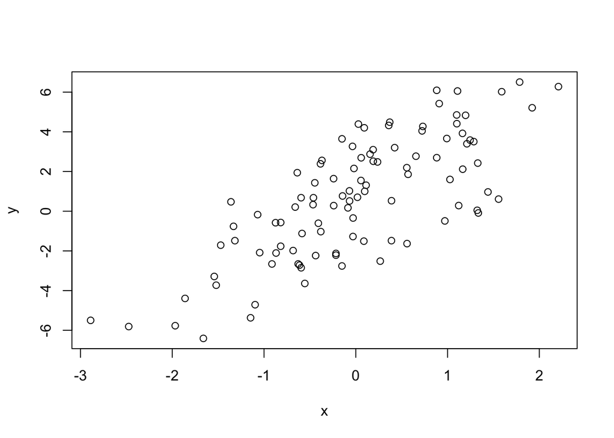

```r
plot(x,y)
```

### 4.3.1 when x is binary

```r
set.seed(10)
x <- rbinom(100,1,0.5)
e <- rnorm(100,0,2)
y <- 0.5 + 2 * x +e
summary(y)
```

```
##    Min. 1st Qu.  Median    Mean 3rd Qu.    Max.
## -3.4936 -0.1409  1.5767  1.4322  2.8397  6.9410
```

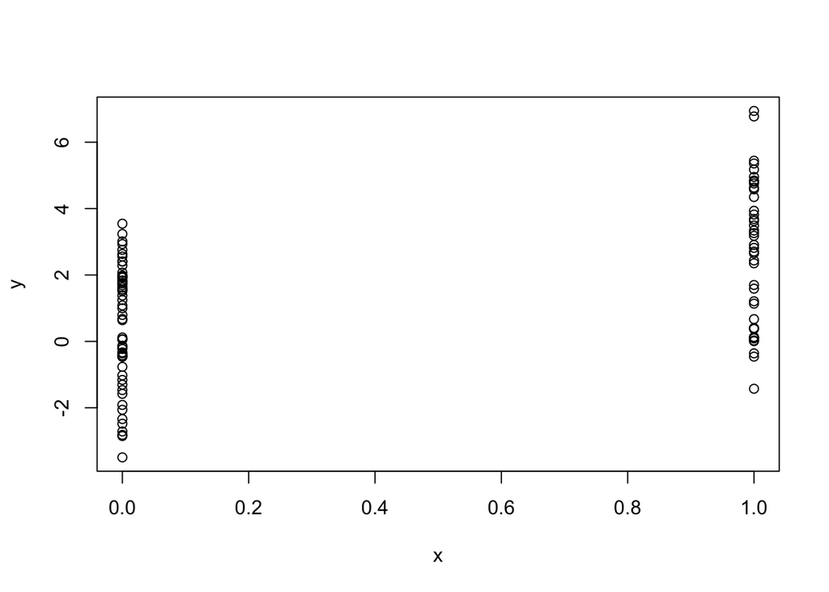

```r
plot(x,y)
```

### 4.3.2 Simulate from a Poisson model

$$Y \sim Poisson(\mu)$$
,
$$\log_\mu = \beta_0 + \beta_1 x$$
and
$$\beta_0 = 0.5, \beta_1 = 0.3$$
, we need to use the `rpois` function for this

```r
set.seed(1)
x <- rnorm(100)
log.mu <- 0.5 + 0.3 * x
y <- rpois(100, exp(log.mu))
summary(y)
```

```
##    Min. 1st Qu.  Median    Mean 3rd Qu.    Max.
##    0.00    1.00    1.00    1.55    2.00    6.00
```

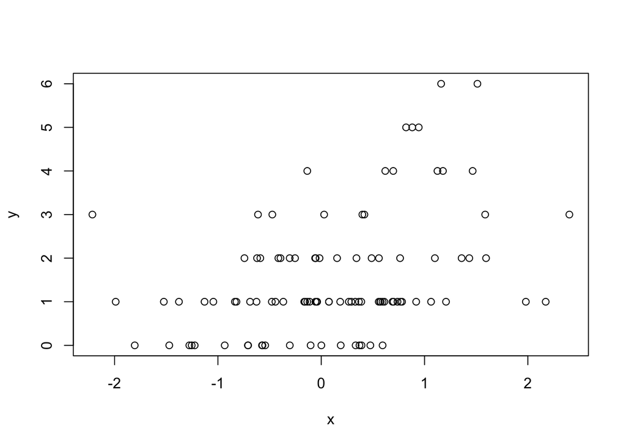

```r
plot(x, y)
```